# Analiza ekspresji białek efryn i ich receptorów na podstawie danych zgromadzonych w rekordzie bazy danych GEO - GDS1375

Aleksandra Gomółka

Przeprowadzono analizę ekspresji 8 efryn, oznaczonych kolejno: efna1, efna2, efna3, efna4, efna5, efnb1, efnb2, efnb3 oraz 11 receptorów efryn, oznaczonych kolejno epha1, epha2, epha3, epha4, epha5, epha7, ephb1, ephb2, ephb3, ephb4, ephb6. Analizę wykonano dla 70 próbek odpowiadających trzem typom stanów chorobowych: 45 czerniaków pierwotnych, 18 łagodnych znamion i 7 normalnych tkanek skóry. W celu porównania wyników w różnych grupach (w próbkach odpowiadających różnym stanom chorobowym) wybrano nieparametryczny test statystyczny Kruskala-Wallisa oraz test post-hoc Dunna.

# Efryny - analiza ekspresji

## A1

**Statystyka graficzna z normalizacją Log2**

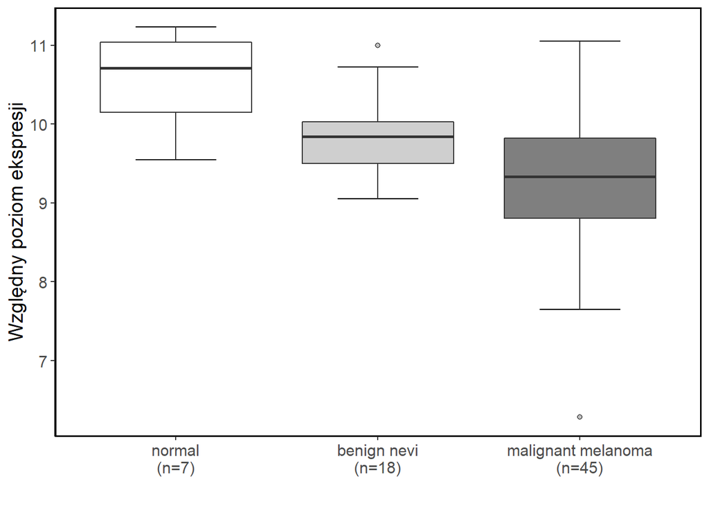

**Statystyka opisowa**

```
## # A tibble: 3 x 7
##   State               mean median maximum minimum    sd     N
##   <chr>              <dbl>  <dbl>   <dbl>   <dbl> <dbl> <int>
## 1 benign nevi         9.87   9.84    11.0    9.06 0.527    18
## 2 malignant melanoma  9.30   9.33    11.1    6.28 0.866    45
## 3 normal             10.6   10.7     11.2    9.55 0.620     7
```

**Test nieparametryczny**

Z uwagi na małą liczbę obserwacji do analizy istotności wyników wykorzystano test nieparametryczny Kruskala-Wallisa .

```
##
##  Kruskal-Wallis rank sum test
##
## data:  data$NormLog2_value by data$State
## Kruskal-Wallis chi-squared = 15.769, df = 2, p-value = 0.0003766
```

Na podstawie otrzymanego wyniku (p-value < 0.05) możemy stwierdzić, że należy odrzucić hipotezę zerową i przyjąć hipotezę alternatywną, która mówi, że występują istotne statystycznie różnice pomiędzy badanymi grupami.

**Testy post-hoc**

```
## Dunn (1964) Kruskal-Wallis multiple comparison
```

```
##   p-values adjusted with the Bonferroni method.
```

```
##                         Comparison         Z      P.unadj       P.adj
## 1 benign nevi - malignant melanoma  2.376626 0.0174717939 0.052415382
## 2             benign nevi - normal -1.782522 0.0746641290 0.223992387
## 3      malignant melanoma - normal -3.585551 0.0003363678 0.001009103
```

## A2

**Statystyka graficzna z normalizacją Log2**

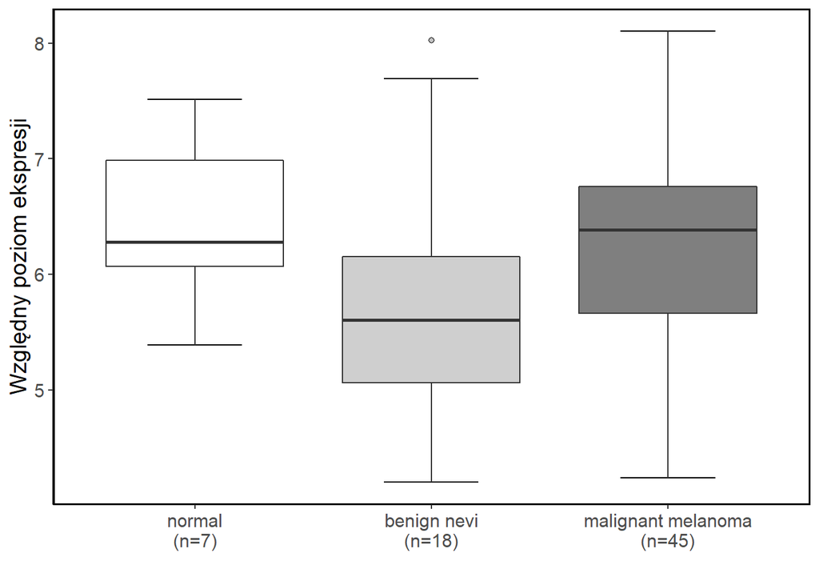

**Statystyka opisowa**

```
## # A tibble: 3 x 7
##   State               mean median maximum minimum    sd     N
##   <chr>              <dbl>  <dbl>   <dbl>   <dbl> <dbl> <int>
## 1 benign nevi         5.79   5.61    8.03    4.20 1.08     18
## 2 malignant melanoma  6.27   6.39    8.10    4.24 0.842    45
## 3 normal              6.47   6.28    7.51    5.39 0.734     7
```

**Test nieparametryczny**

Z uwagi na małą liczbę obserwacji do analizy istotności wyników wykorzystano test nieparametryczny Kruskala-Wallisa .

```
##
##  Kruskal-Wallis rank sum test
##
## data:  data$NormLog2_value by data$State
## Kruskal-Wallis chi-squared = 5.1429, df = 2, p-value = 0.07643
```

Na podstawie uzyskanego wyniku (p-values > 0.05) możemy stwierdzić, że należy przyjąć hipotezę zerową, która mówi, że brak istotnych statystycznie różnic pomiędzy badanymi grupami.

## A3

**Statystyka graficzna z normalizacją Log2**

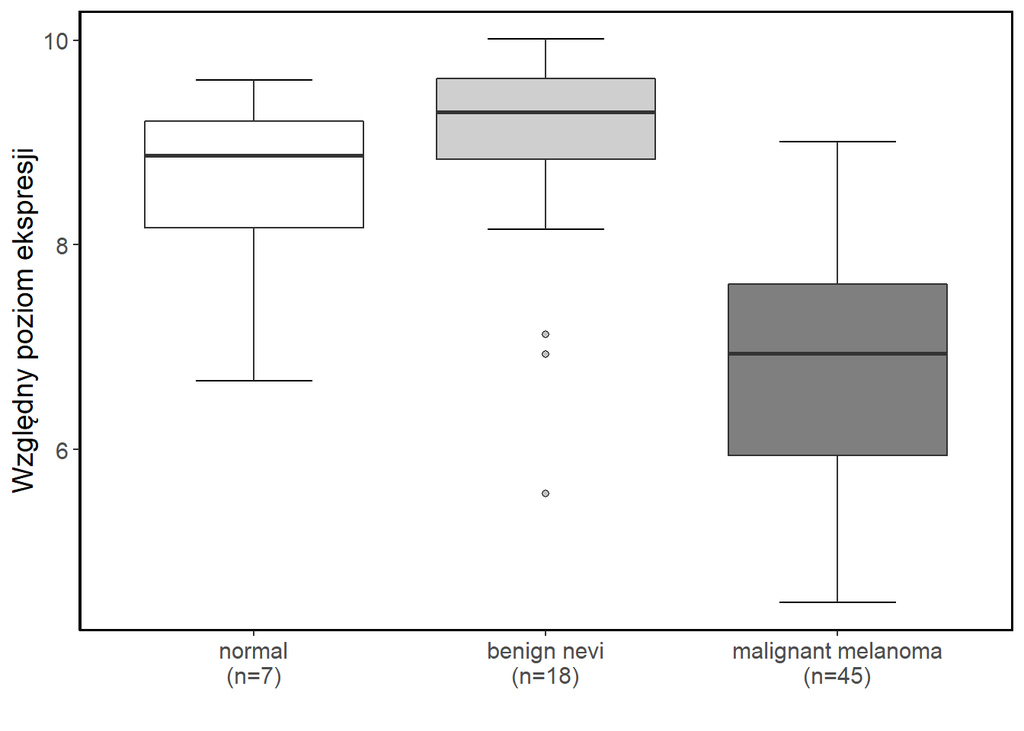

**Statystyka opisowa**

```
## # A tibble: 3 x 7
##   State               mean median maximum minimum    sd     N
##   <chr>              <dbl>  <dbl>   <dbl>   <dbl> <dbl> <int>
## 1 benign nevi         8.87   9.30   10.0     5.57  1.19    18
## 2 malignant melanoma  6.78   6.94    9.00    4.50  1.23    45
## 3 normal              8.56   8.88    9.61    6.67  1.01     7
```

**Test nieparametryczny**

Z uwagi na małą liczbę obserwacji do analizy istotności wyników wykorzystano test nieparametryczny Kruskala-Wallisa .

```
##
##  Kruskal-Wallis rank sum test
##
## data:  data$NormLog2_value by data$State
## Kruskal-Wallis chi-squared = 28.097, df = 2, p-value = 7.92e-07
```

Na podstawie otrzymanego wyniku (p-value < 0.05) możemy stwierdzić, że należy odrzucić hipotezę zerową i przyjąć hipotezę alternatywną, która mówi, że występują istotne statystycznie różnice pomiędzy badanymi grupami.

**Testy post-hoc**

```
## Dunn (1964) Kruskal-Wallis multiple comparison
```

```
##   p-values adjusted with the Bonferroni method.
```

```
##                         Comparison          Z      P.unadj        P.adj
## 1 benign nevi - malignant melanoma  4.9451048 7.610291e-07 2.283087e-06
## 2             benign nevi - normal  0.5042892 6.140582e-01 1.000000e+00
## 3      malignant melanoma - normal -2.8414884 4.490349e-03 1.347105e-02
```

Wartości p-value mniejsze od 0.05 oznaczają, że względny poziom ekspresji efryn między różnymi stanami chorobowymi jest istotny statystycznie. Dla efryny A3 test Dunna wykazał istotne statystycznie różnice w benign nevi-malignant melanoma oraz malignant melanoma-normal.

## A4

**Statystyka graficzna z normalizacją Log2**

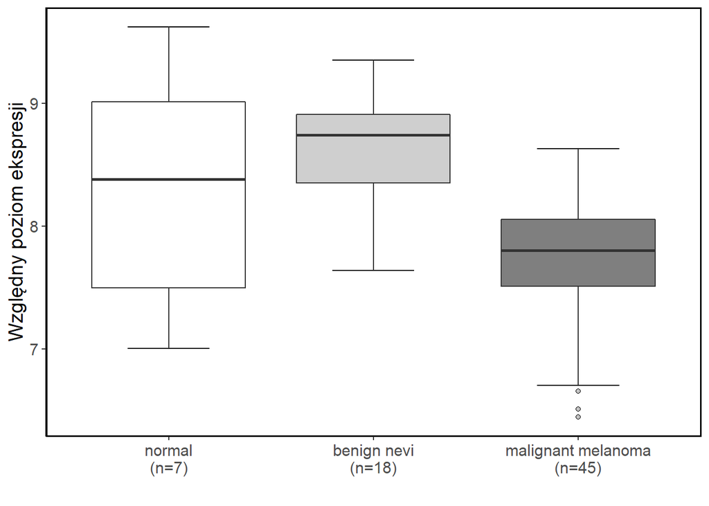

**Statystyka opisowa**

```
## # A tibble: 3 x 7
##   State               mean median maximum minimum    sd     N
##   <chr>              <dbl>  <dbl>   <dbl>   <dbl> <dbl> <int>
## 1 benign nevi         8.62   8.74    9.35    7.64 0.524    18
## 2 malignant melanoma  7.75   7.80    8.63    6.44 0.495    45
## 3 normal              8.29   8.38    9.62    7.00 1.02      7
```

**Test nieparametryczny**

Z uwagi na małą liczbę obserwacji do analizy istotności wyników wykorzystano test nieparametryczny Kruskala-Wallisa .

```
##
##  Kruskal-Wallis rank sum test
##
## data:  data$NormLog2_value by data$State
## Kruskal-Wallis chi-squared = 21.345, df = 2, p-value = 2.318e-05
```

Na podstawie otrzymanego wyniku (p-value < 0.05) możemy stwierdzić, że należy odrzucić hipotezę zerową i przyjąć hipotezę alternatywną, która mówi, że występują istotne statystycznie różnice pomiędzy badanymi grupami.

**Testy post-hoc**

```
## Dunn (1964) Kruskal-Wallis multiple comparison
```

```
##   p-values adjusted with the Bonferroni method.
```

```
##                         Comparison         Z      P.unadj        P.adj
## 1 benign nevi - malignant melanoma  4.602551 4.173479e-06 1.252044e-05
## 2             benign nevi - normal  1.699364 8.925057e-02 2.677517e-01
## 3      malignant melanoma - normal -1.296169 1.949172e-01 5.847515e-01
```

Wartości p-value mniejsze od 0.05 oznaczają, że względny poziom ekspresji efryn między różnymi stanami chorobowymi jest istotny statystycznie. Dla efryny A4 test Dunna wykazał istotne statystycznie różnice w benign nevi-malignant melanoma.

## A5

**Statystyka graficzna z normalizacją Log2**

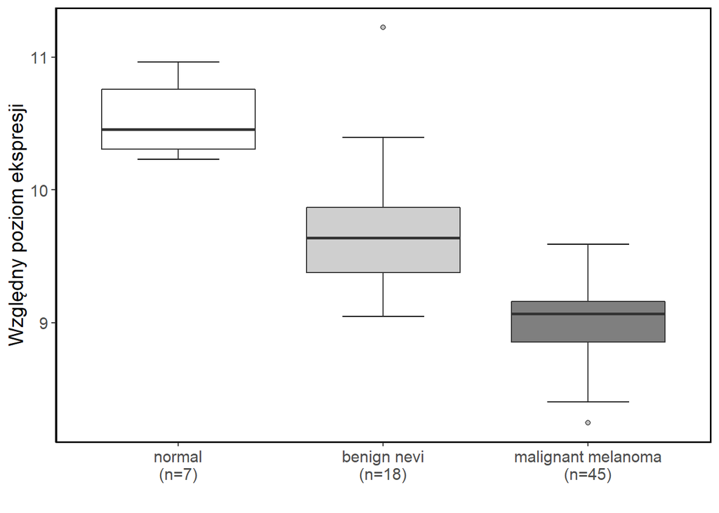

**Statystyka opisowa**

```
## # A tibble: 3 x 7
##   State               mean median maximum minimum    sd     N
##   <chr>              <dbl>  <dbl>   <dbl>   <dbl> <dbl> <int>
## 1 benign nevi         9.68   9.64   11.2     9.05 0.510    18
## 2 malignant melanoma  9.03   9.07    9.59    8.25 0.313    45
## 3 normal             10.5   10.5    11.0    10.2  0.288     7
```

**Test nieparametryczny**

Z uwagi na małą liczbę obserwacji do analizy istotności wyników wykorzystano test nieparametryczny Kruskala-Wallisa .

```
##
##  Kruskal-Wallis rank sum test
##
## data:  data$NormLog2_value by data$State
## Kruskal-Wallis chi-squared = 38.709, df = 2, p-value = 3.93e-09
```

Na podstawie otrzymanego wyniku (p-value < 0.05) możemy stwierdzić, że należy odrzucić hipotezę zerową i przyjąć hipotezę alternatywną, która mówi, że występują istotne statystycznie różnice pomiędzy badanymi grupami.

**Testy post-hoc**

```
## Dunn (1964) Kruskal-Wallis multiple comparison
```

```
##   p-values adjusted with the Bonferroni method.
```

```
##                         Comparison         Z      P.unadj        P.adj
## 1 benign nevi - malignant melanoma  4.661241 3.143086e-06 9.429257e-06
## 2             benign nevi - normal -1.601293 1.093120e-01 3.279360e-01
## 3      malignant melanoma - normal -4.955040 7.231551e-07 2.169465e-06
```

Wartości p-value mniejsze od 0.05 oznaczają, że względny poziom ekspresji efryn między różnymi stanami chorobowymi jest istotny statystycznie. Dla efryny A5 test Dunna wykazał istotne statystycznie różnice w benign nevi-malignant melanoma oraz malignant melanoma-normal.

## B1

**Statystyka graficzna z normalizacją Log2**

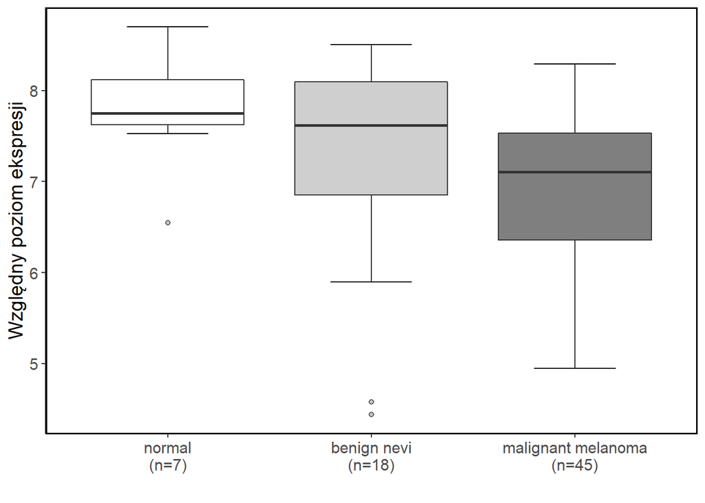

**Statystyka opisowa**

```
## # A tibble: 3 x 7
##   State               mean median maximum minimum    sd     N
##   <chr>              <dbl>  <dbl>   <dbl>   <dbl> <dbl> <int>
## 1 benign nevi         7.25   7.62    8.50    4.44 1.19     18
## 2 malignant melanoma  6.97   7.11    8.30    4.95 0.820    45
## 3 normal              7.78   7.75    8.70    6.55 0.667     7
```

**Test nieparametryczny**

Z uwagi na małą liczbę obserwacji do analizy istotności wyników wykorzystano test nieparametryczny Kruskala-Wallisa .

```
##
##  Kruskal-Wallis rank sum test
##
## data:  data$NormLog2_value by data$State
## Kruskal-Wallis chi-squared = 7.5, df = 2, p-value = 0.02352
```

Na podstawie otrzymanego wyniku (p-value < 0.05) możemy stwierdzić, że należy odrzucić hipotezę zerową i przyjąć hipotezę alternatywną, która mówi, że występują istotne statystycznie różnice pomiędzy badanymi grupami.

**Testy post-hoc**

```
## Dunn (1964) Kruskal-Wallis multiple comparison
```

```
##   p-values adjusted with the Bonferroni method.
```

```
##                         Comparison         Z    P.unadj      P.adj
## 1 benign nevi - malignant melanoma  1.820644 0.06866095 0.20598284
## 2             benign nevi - normal -1.015582 0.30982832 0.92948495
## 3      malignant melanoma - normal -2.363108 0.01812240 0.05436719
```

## B2

**Statystyka graficzna z normalizacją Log2**

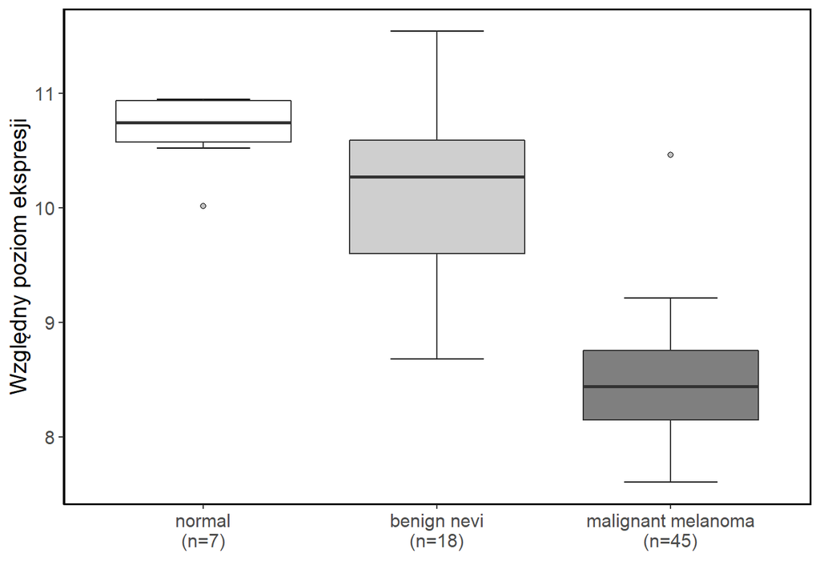

**Statystyka opisowa**

```
## # A tibble: 3 x 7
##   State               mean median maximum minimum    sd     N
##   <chr>              <dbl>  <dbl>   <dbl>   <dbl> <dbl> <int>
## 1 benign nevi        10.1   10.3     11.5    8.68 0.826    18
## 2 malignant melanoma  8.45   8.44    10.5    7.61 0.509    45
## 3 normal             10.7   10.7     10.9   10.0  0.336     7
```

**Test nieparametryczny**

Z uwagi na małą liczbę obserwacji do analizy istotności wyników wykorzystano test nieparametryczny Kruskala-Wallisa .

```
##
##  Kruskal-Wallis rank sum test
##
## data:  data$NormLog2_value by data$State
## Kruskal-Wallis chi-squared = 42.601, df = 2, p-value = 5.614e-10
```

Na podstawie otrzymanego wyniku (p-value < 0.05) możemy stwierdzić, że należy odrzucić hipotezę zerową i przyjąć hipotezę alternatywną, która mówi, że występują istotne statystycznie różnice pomiędzy badanymi grupami.

**Testy post-hoc**

```
## Dunn (1964) Kruskal-Wallis multiple comparison
```

```
##   p-values adjusted with the Bonferroni method.
```

```
##                         Comparison          Z      P.unadj        P.adj
## 1 benign nevi - malignant melanoma  5.4364830 5.434252e-08 1.630276e-07
## 2             benign nevi - normal -0.7993333 4.240971e-01 1.000000e+00
## 3      malignant melanoma - normal -4.6079643 4.066305e-06 1.219892e-05
```

Wartości p-value mniejsze od 0.05 oznaczają, że względny poziom ekspresji efryn między różnymi stanami chorobowymi jest istotny statystycznie. Dla efryny B2 test Dunna wykazał istotne statystycznie różnice w benign nevi-malignant melanoma oraz malignant melanoma-normal.

## B3

**Statystyka graficzna z normalizacją Log2**

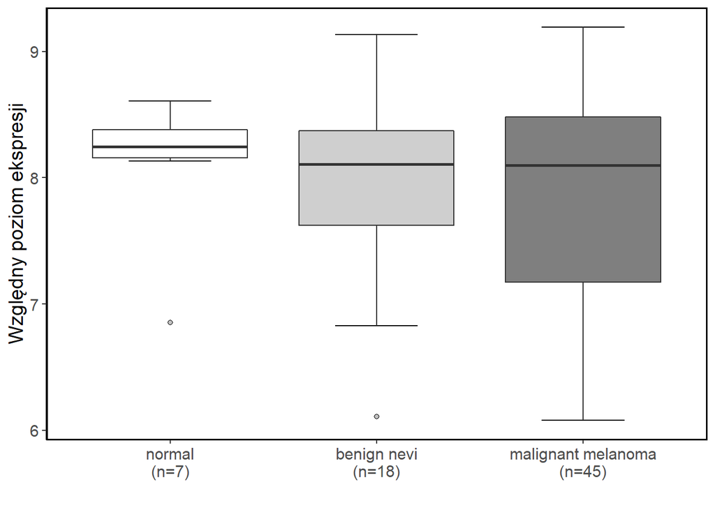

**Statystyka opisowa**

```
## # A tibble: 3 x 7
##   State               mean median maximum minimum    sd     N
##   <chr>              <dbl>  <dbl>   <dbl>   <dbl> <dbl> <int>
## 1 benign nevi         7.96   8.10    9.13    6.11 0.725    18
## 2 malignant melanoma  7.89   8.10    9.19    6.08 0.830    45
## 3 normal              8.11   8.25    8.61    6.85 0.577     7
```

**Test nieparametryczny**

Z uwagi na małą liczbę obserwacji do analizy istotności wyników wykorzystano test nieparametryczny Kruskala-Wallisa .

```
##
##  Kruskal-Wallis rank sum test
##
## data:  data$NormLog2_value by data$State
## Kruskal-Wallis chi-squared = 0.61087, df = 2, p-value = 0.7368
```

Na podstawie uzyskanego wyniku (p-values > 0.05) możemy stwierdzić, że należy przyjąć hipotezę zerową, która mówi, że brak istotnych statystycznie różnic pomiędzy badanymi grupami.

# Podsumowanie - efryny wykazujące różnice w poziomie ekspresji w zależności od stanu chorobowego

Istotne statystycznie różnice w pozimie ekspresji efryn dla czerniaków pierwotnych, łagodnych znamion i normalnych tkanek skóry uzyskano dla efryn **A1**, **A3**, **A4**, **A5**, **B1** oraz **B2**.

**–>** Dla efryny **A3** test Dunna wykazał istotne statystycznie różnice w **benign nevi-malignant melanoma** oraz **malignant melanoma-normal**.

**–>** Dla efryny **A4** test Dunna wykazał istotne statystycznie różnice w **benign nevi-malignant melanoma**.

**–>** Dla efryny **A5** test Dunna wykazał istotne statystycznie różnice w **benign nevi-malignant melanoma** oraz **malignant melanoma-normal**.

**–>** Dla efryny **B2** test Dunna wykazał istotne statystycznie różnice w **benign nevi-malignant melanoma** oraz **malignant melanoma-normal**.

# Receptory - analiza ekspresji

## A1

**Statystyka graficzna z normalizacją Log2**

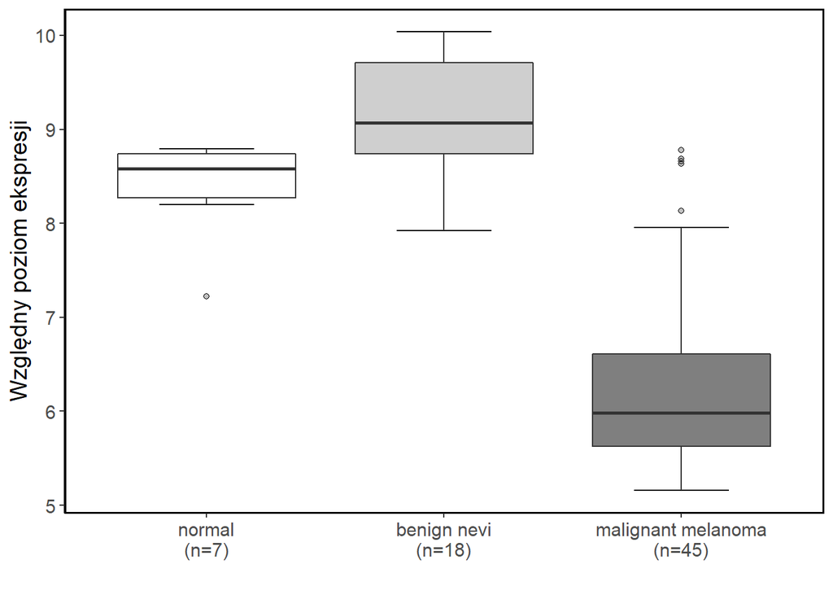

**Statystyka opisowa**

```
## # A tibble: 3 x 7
##   State               mean median maximum minimum    sd     N
##   <chr>              <dbl>  <dbl>   <dbl>   <dbl> <dbl> <int>
## 1 benign nevi         9.12   9.07   10.0     7.92 0.612    18
## 2 malignant melanoma  6.33   5.99    8.78    5.16 1.02     45
## 3 normal              8.37   8.58    8.79    7.22 0.553     7
```

**Test nieparametryczny**

Z uwagi na małą liczbę obserwacji do analizy istotności wyników wykorzystano test nieparametryczny Kruskala-Wallisa .

```
##
##  Kruskal-Wallis rank sum test
##
## data:  data$NormLog2_value by data$State
## Kruskal-Wallis chi-squared = 42.009, df = 2, p-value = 7.548e-10
```

Na podstawie otrzymanego wyniku (p-value < 0.05) możemy stwierdzić, że należy odrzucić hipotezę zerową i przyjąć hipotezę alternatywną, która mówi, że występują istotne statystycznie różnice pomiędzy badanymi grupami.

**Testy post-hoc**

```
## Dunn (1964) Kruskal-Wallis multiple comparison
```

```
##   p-values adjusted with the Bonferroni method.
```

```
##                         Comparison         Z      P.unadj        P.adj
## 1 benign nevi - malignant melanoma  6.217598 5.048225e-10 1.514467e-09
## 2             benign nevi - normal  1.143406 2.528702e-01 7.586106e-01
## 3      malignant melanoma - normal -3.014258 2.576084e-03 7.728253e-03
```

Wartości p-value mniejsze od 0.05 oznaczają, że względny poziom ekspresji efryn między różnymi stanami chorobowymi jest istotny statystycznie. Dla receptora A1 test Dunna wykazał istotne statystycznie różnice w benign nevi-malignant melanoma oraz malignant melanoma-normal.

## A2

**Statystyka graficzna z normalizacją Log2**

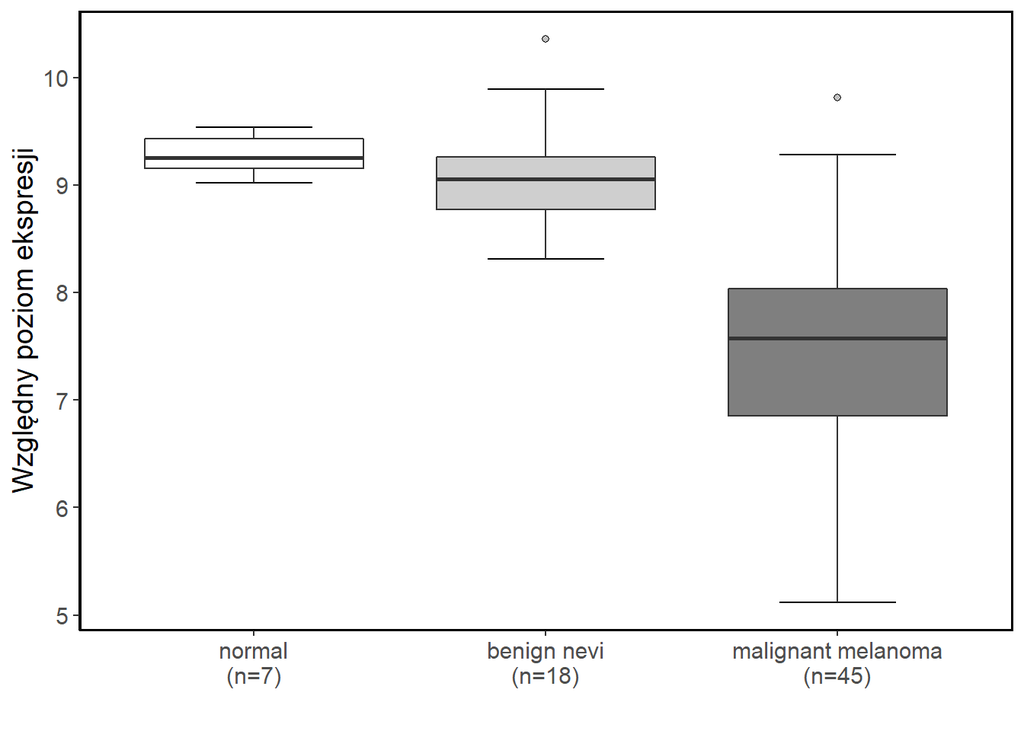

**Statystyka opisowa**

```
## # A tibble: 3 x 7
##   State               mean median maximum minimum    sd     N
##   <chr>              <dbl>  <dbl>   <dbl>   <dbl> <dbl> <int>
## 1 benign nevi         9.05   9.06   10.4     8.31 0.531    18
## 2 malignant melanoma  7.50   7.58    9.81    5.12 1.05     45
## 3 normal              9.28   9.26    9.54    9.02 0.189     7
```

**Test nieparametryczny**

Z uwagi na małą liczbę obserwacji do analizy istotności wyników wykorzystano test nieparametryczny Kruskala-Wallisa .

```
##
##  Kruskal-Wallis rank sum test
##
## data:  data$NormLog2_value by data$State
## Kruskal-Wallis chi-squared = 33.086, df = 2, p-value = 6.538e-08
```

Na podstawie otrzymanego wyniku (p-value < 0.05) możemy stwierdzić, że należy odrzucić hipotezę zerową i przyjąć hipotezę alternatywną, która mówi, że występują istotne statystycznie różnice pomiędzy badanymi grupami.

**Testy post-hoc**

```
## Dunn (1964) Kruskal-Wallis multiple comparison
```

```
##   p-values adjusted with the Bonferroni method.
```

```
##                         Comparison          Z      P.unadj        P.adj
## 1 benign nevi - malignant melanoma  4.7258444 2.291611e-06 6.874832e-06
## 2             benign nevi - normal -0.8194699 4.125184e-01 1.000000e+00
## 3      malignant melanoma - normal -4.1422535 3.439099e-05 1.031730e-04
```

Wartości p-value mniejsze od 0.05 oznaczają, że względny poziom ekspresji efryn między różnymi stanami chorobowymi jest istotny statystycznie. Dla receptora A2 test Dunna wykazał istotne statystycznie różnice w benign nevi-malignant melanoma oraz malignant melanoma-normal.

## A3

**Statystyka graficzna z normalizacją Log2**

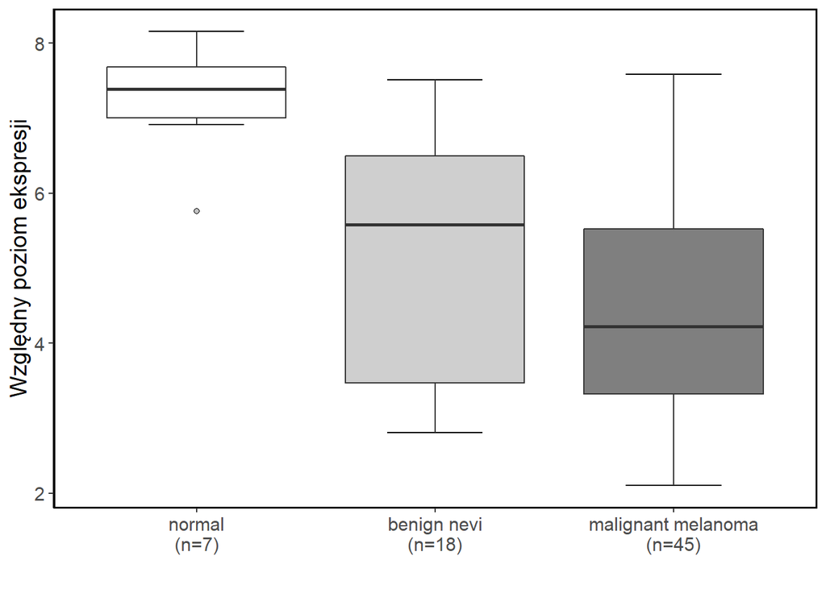

**Statystyka opisowa**

```
## # A tibble: 3 x 7
##   State               mean median maximum minimum    sd     N
##   <chr>              <dbl>  <dbl>   <dbl>   <dbl> <dbl> <int>
## 1 benign nevi         5.06   5.58    7.51    2.81 1.63     18
## 2 malignant melanoma  4.38   4.22    7.58    2.10 1.36     45
## 3 normal              7.24   7.39    8.16    5.77 0.770     7
```

**Test nieparametryczny**

Z uwagi na małą liczbę obserwacji do analizy istotności wyników wykorzystano test nieparametryczny Kruskala-Wallisa .

```
##
##  Kruskal-Wallis rank sum test
##
## data:  data$NormLog2_value by data$State
## Kruskal-Wallis chi-squared = 16.465, df = 2, p-value = 0.0002658
```

Na podstawie otrzymanego wyniku (p-value < 0.05) możemy stwierdzić, że należy odrzucić hipotezę zerową i przyjąć hipotezę alternatywną, która mówi, że występują istotne statystycznie różnice pomiędzy badanymi grupami.

**Testy post-hoc**

```
## Dunn (1964) Kruskal-Wallis multiple comparison
```

```
##   p-values adjusted with the Bonferroni method.
```

```
##                         Comparison         Z      P.unadj        P.adj
## 1 benign nevi - malignant melanoma  1.347888 1.776945e-01 0.5330835533
## 2             benign nevi - normal -2.820479 4.795200e-03 0.0143855990
## 3      malignant melanoma - normal -4.017354 5.885538e-05 0.0001765661
```

Wartości p-value mniejsze od 0.05 oznaczają, że względny poziom ekspresji efryn między różnymi stanami chorobowymi jest istotny statystycznie. Dla receptora A3 test Dunna wykazał istotne statystycznie różnice w benign nevi-normal oraz malignant melanoma-normal.

## A4

**Statystyka graficzna z normalizacją Log2**

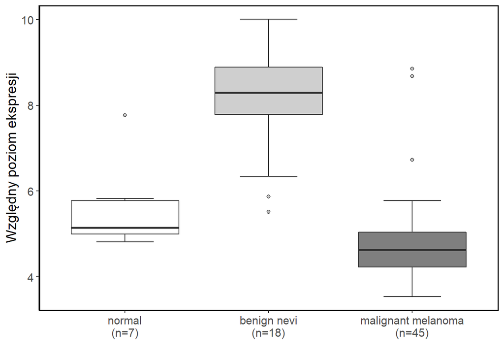

**Statystyka opisowa**

```
## # A tibble: 3 x 7
##   State               mean median maximum minimum    sd     N
##   <chr>              <dbl>  <dbl>   <dbl>   <dbl> <dbl> <int>
## 1 benign nevi         8.17   8.29   10.0     5.51  1.29    18
## 2 malignant melanoma  4.82   4.63    8.85    3.54  1.07    45
## 3 normal              5.61   5.15    7.77    4.82  1.03     7
```

**Test nieparametryczny**

Z uwagi na małą liczbę obserwacji do analizy istotności wyników wykorzystano test nieparametryczny Kruskala-Wallisa .

```
##
##  Kruskal-Wallis rank sum test
##
## data:  data$NormLog2_value by data$State
## Kruskal-Wallis chi-squared = 37.168, df = 2, p-value = 8.495e-09
```

Na podstawie otrzymanego wyniku (p-value < 0.05) możemy stwierdzić, że należy odrzucić hipotezę zerową i przyjąć hipotezę alternatywną, która mówi, że występują istotne statystycznie różnice pomiędzy badanymi grupami.

**Testy post-hoc**

```
## Dunn (1964) Kruskal-Wallis multiple comparison
```

```
##   p-values adjusted with the Bonferroni method.
```

```
##                         Comparison         Z      P.unadj        P.adj
## 1 benign nevi - malignant melanoma  6.047280 1.473118e-09 4.419354e-09
## 2             benign nevi - normal  2.012779 4.413787e-02 1.324136e-01
## 3      malignant melanoma - normal -1.944237 5.186689e-02 1.556007e-01
```

Wartości p-value mniejsze od 0.05 oznaczają, że względny poziom ekspresji efryn między różnymi stanami chorobowymi jest istotny statystycznie. Dla receptora A4 test Dunna wykazał istotne statystycznie różnice w benign nevi-malignant melanoma.

## A5

**Statystyka graficzna z normalizacją Log2**

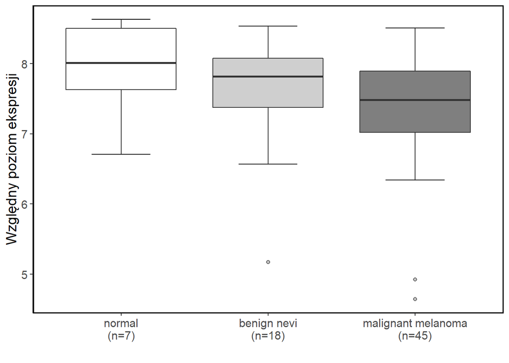

**Statystyka opisowa**

```
## # A tibble: 3 x 7
##   State               mean median maximum minimum    sd     N
##   <chr>              <dbl>  <dbl>   <dbl>   <dbl> <dbl> <int>
## 1 benign nevi         7.61   7.81    8.54    5.17 0.794    18
## 2 malignant melanoma  7.36   7.48    8.51    4.64 0.768    45
## 3 normal              7.94   8.01    8.63    6.71 0.689     7
```

**Test nieparametryczny**

Z uwagi na małą liczbę obserwacji do analizy istotności wyników wykorzystano test nieparametryczny Kruskala-Wallisa .

```
##
##  Kruskal-Wallis rank sum test
##
## data:  data$NormLog2_value by data$State
## Kruskal-Wallis chi-squared = 5.4497, df = 2, p-value = 0.06556
```

Na podstawie uzyskanego wyniku (p-values > 0.05) możemy stwierdzić, że należy przyjąć hipotezę zerową, która mówi, że brak istotnych statystycznie różnic pomiędzy badanymi grupami.

## A7

**Statystyka graficzna z normalizacją Log2**

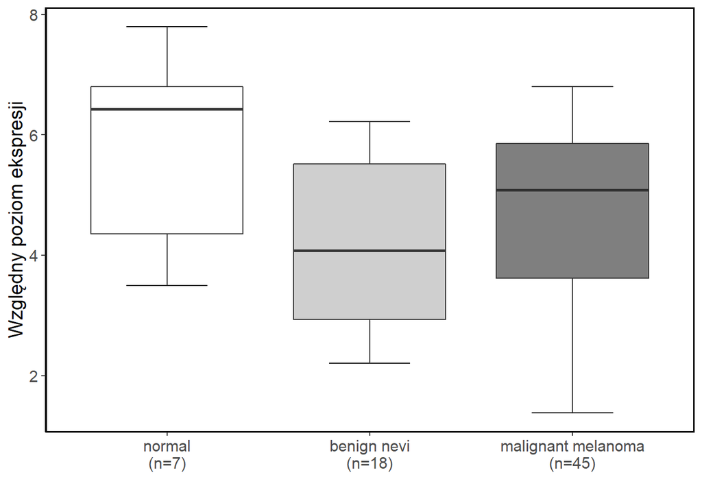

**Statystyka opisowa**

```
## # A tibble: 3 x 7
##   State               mean median maximum minimum    sd     N
##   <chr>              <dbl>  <dbl>   <dbl>   <dbl> <dbl> <int>
## 1 benign nevi         4.22   4.08    6.22    2.20  1.44    18
## 2 malignant melanoma  4.69   5.08    6.80    1.38  1.42    45
## 3 normal              5.72   6.43    7.80    3.50  1.63     7
```

**Test nieparametryczny**

Z uwagi na małą liczbę obserwacji do analizy istotności wyników wykorzystano test nieparametryczny Kruskala-Wallisa .

```
##
##  Kruskal-Wallis rank sum test
##
## data:  data$NormLog2_value by data$State
## Kruskal-Wallis chi-squared = 5.5385, df = 2, p-value = 0.06271
```

Na podstawie uzyskanego wyniku (p-values > 0.05) możemy stwierdzić, że należy przyjąć hipotezę zerową, która mówi, że brak istotnych statystycznie różnic pomiędzy badanymi grupami.

## B1

**Statystyka graficzna z normalizacją Log2**

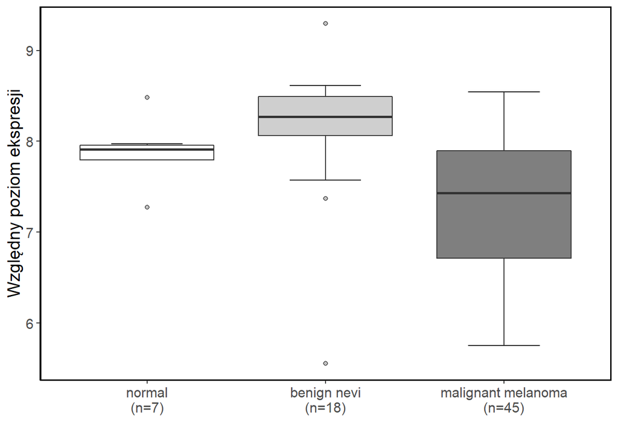

**Statystyka opisowa**

```
## # A tibble: 3 x 7
##   State               mean median maximum minimum    sd     N
##   <chr>              <dbl>  <dbl>   <dbl>   <dbl> <dbl> <int>
## 1 benign nevi         8.12   8.27    9.30    5.55 0.767    18
## 2 malignant melanoma  7.36   7.43    8.54    5.75 0.755    45
## 3 normal              7.88   7.91    8.48    7.28 0.355     7
```

**Test nieparametryczny**

Z uwagi na małą liczbę obserwacji do analizy istotności wyników wykorzystano test nieparametryczny Kruskala-Wallisa .

```
##
##  Kruskal-Wallis rank sum test
##
## data:  data$NormLog2_value by data$State
## Kruskal-Wallis chi-squared = 16.69, df = 2, p-value = 0.0002376
```

Na podstawie otrzymanego wyniku (p-value < 0.05) możemy stwierdzić, że należy odrzucić hipotezę zerową i przyjąć hipotezę alternatywną, która mówi, że występują istotne statystycznie różnice pomiędzy badanymi grupami.

**Testy post-hoc**

```
## Dunn (1964) Kruskal-Wallis multiple comparison
```

```
##   p-values adjusted with the Bonferroni method.
```

```
##                         Comparison         Z      P.unadj        P.adj
## 1 benign nevi - malignant melanoma  4.015206 5.939394e-05 0.0001781818
## 2             benign nevi - normal  1.121518 2.620674e-01 0.7862021924
## 3      malignant melanoma - normal -1.526518 1.268810e-01 0.3806429276
```

Wartości p-value mniejsze od 0.05 oznaczają, że względny poziom ekspresji efryn między różnymi stanami chorobowymi jest istotny statystycznie. Dla receptora B1 test Dunna wykazał istotne statystycznie różnice w benign nevi-malignant melanoma.

## B2

**Statystyka graficzna z normalizacją Log2**

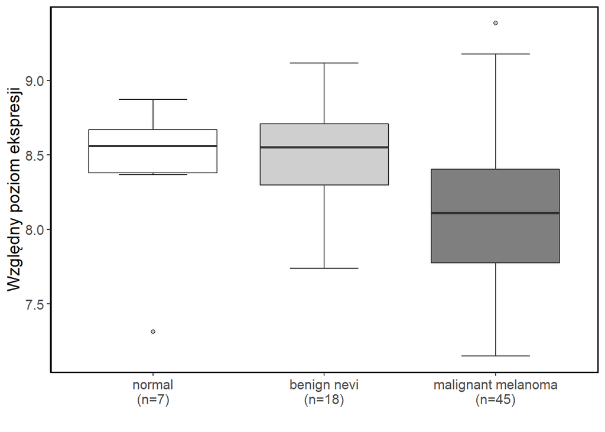

**Statystyka opisowa**

```
## # A tibble: 3 x 7
##   State               mean median maximum minimum    sd     N
##   <chr>              <dbl>  <dbl>   <dbl>   <dbl> <dbl> <int>
## 1 benign nevi         8.51   8.55    9.12    7.74 0.385    18
## 2 malignant melanoma  8.14   8.11    9.39    7.15 0.463    45
## 3 normal              8.41   8.56    8.87    7.31 0.515     7
```

**Test nieparametryczny**

Z uwagi na małą liczbę obserwacji do analizy istotności wyników wykorzystano test nieparametryczny Kruskala-Wallisa .

```
##
##  Kruskal-Wallis rank sum test
##
## data:  data$NormLog2_value by data$State
## Kruskal-Wallis chi-squared = 10.866, df = 2, p-value = 0.00437
```

Na podstawie otrzymanego wyniku (p-value < 0.05) możemy stwierdzić, że należy odrzucić hipotezę zerową i przyjąć hipotezę alternatywną, która mówi, że występują istotne statystycznie różnice pomiędzy badanymi grupami.

**Testy post-hoc**

```
## Dunn (1964) Kruskal-Wallis multiple comparison
```

```
##   p-values adjusted with the Bonferroni method.
```

```
##                         Comparison          Z     P.unadj      P.adj
## 1 benign nevi - malignant melanoma  3.0608626 0.002207003 0.00662101
## 2             benign nevi - normal  0.2744723 0.783721700 1.00000000
## 3      malignant melanoma - normal -1.8000858 0.071847096 0.21554129
```

Wartości p-value mniejsze od 0.05 oznaczają, że względny poziom ekspresji efryn między różnymi stanami chorobowymi jest istotny statystycznie. Dla receptora B2 test Dunna wykazał istotne statystycznie różnice w benign nevi-malignant melanoma.

## B3

**Statystyka graficzna z normalizacją Log2**

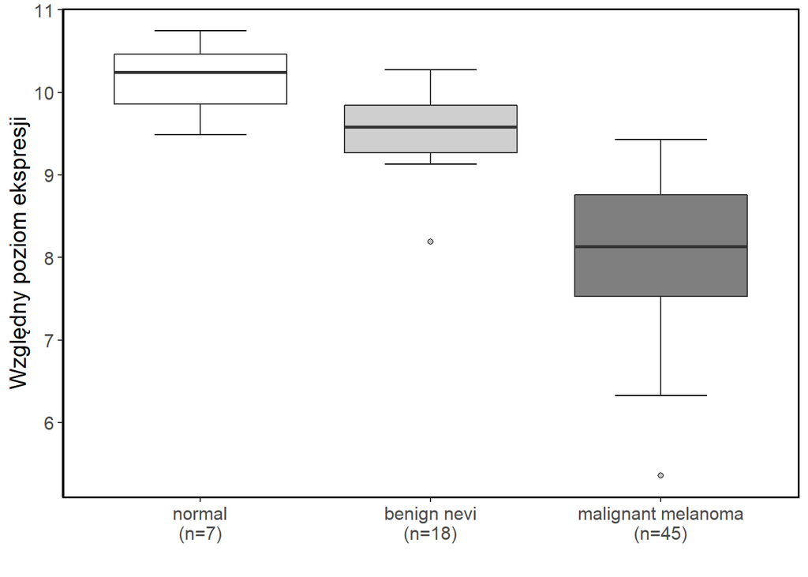

**Statystyka opisowa**

```
## # A tibble: 3 x 7
##   State               mean median maximum minimum    sd     N
##   <chr>              <dbl>  <dbl>   <dbl>   <dbl> <dbl> <int>
## 1 benign nevi         9.56   9.58   10.3     8.19 0.507    18
## 2 malignant melanoma  8.08   8.13    9.43    5.36 0.833    45
## 3 normal             10.2   10.2    10.7     9.49 0.444     7
```

**Test nieparametryczny**

Z uwagi na małą liczbę obserwacji do analizy istotności wyników wykorzystano test nieparametryczny Kruskala-Wallisa .

```
##
##  Kruskal-Wallis rank sum test
##
## data:  data$NormLog2_value by data$State
## Kruskal-Wallis chi-squared = 43.331, df = 2, p-value = 3.898e-10
```

Na podstawie otrzymanego wyniku (p-value < 0.05) możemy stwierdzić, że należy odrzucić hipotezę zerową i przyjąć hipotezę alternatywną, która mówi, że występują istotne statystycznie różnice pomiędzy badanymi grupami.

**Testy post-hoc**

```
## Dunn (1964) Kruskal-Wallis multiple comparison
```

```
##   p-values adjusted with the Bonferroni method.
```

```
##                         Comparison         Z      P.unadj        P.adj
## 1 benign nevi - malignant melanoma  5.313149 1.077469e-07 3.232406e-07
## 2             benign nevi - normal -1.099631 2.714931e-01 8.144794e-01
## 3      malignant melanoma - normal -4.852530 1.218966e-06 3.656897e-06
```

Wartości p-value mniejsze od 0.05 oznaczają, że względny poziom ekspresji efryn między różnymi stanami chorobowymi jest istotny statystycznie. Dla receptora B3 test Dunna wykazał istotne statystycznie różnice w benign nevi-malignant melanoma oraz malignant melanoma-normal.

## B4

**Statystyka graficzna z normalizacją Log2**

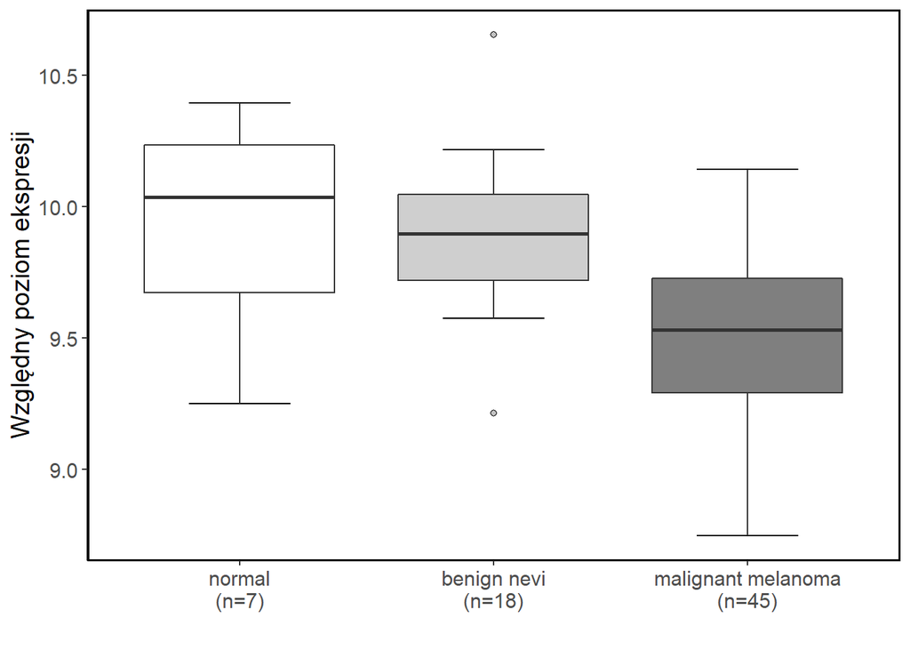

**Statystyka opisowa**

```
## # A tibble: 3 x 7
##   State               mean median maximum minimum    sd     N
##   <chr>              <dbl>  <dbl>   <dbl>   <dbl> <dbl> <int>
## 1 benign nevi         9.88   9.90    10.7    9.21 0.304    18
## 2 malignant melanoma  9.51   9.53    10.1    8.75 0.351    45
## 3 normal              9.93  10.0     10.4    9.25 0.411     7
```

**Test nieparametryczny**

Z uwagi na małą liczbę obserwacji do analizy istotności wyników wykorzystano test nieparametryczny Kruskala-Wallisa .

```
##
##  Kruskal-Wallis rank sum test
##
## data:  data$NormLog2_value by data$State
## Kruskal-Wallis chi-squared = 15.353, df = 2, p-value = 0.0004635
```

Na podstawie otrzymanego wyniku (p-value < 0.05) możemy stwierdzić, że należy odrzucić hipotezę zerową i przyjąć hipotezę alternatywną, która mówi, że występują istotne statystycznie różnice pomiędzy badanymi grupami.

**Testy post-hoc**

```
## Dunn (1964) Kruskal-Wallis multiple comparison
```

```
##   p-values adjusted with the Bonferroni method.
```

```
##                         Comparison          Z      P.unadj      P.adj
## 1 benign nevi - malignant melanoma  3.4435627 0.0005741035 0.00172231
## 2             benign nevi - normal -0.1322008 0.8948254646 1.00000000
## 3      malignant melanoma - normal -2.5086184 0.0121204328 0.03636130
```

Wartości p-value mniejsze od 0.05 oznaczają, że względny poziom ekspresji efryn między różnymi stanami chorobowymi jest istotny statystycznie. Dla receptora B4 test Dunna wykazał istotne statystycznie różnice w benign nevi-malignant melanoma oraz malignant melanoma-normal.

## B6

**Statystyka graficzna z normalizacją Log2**

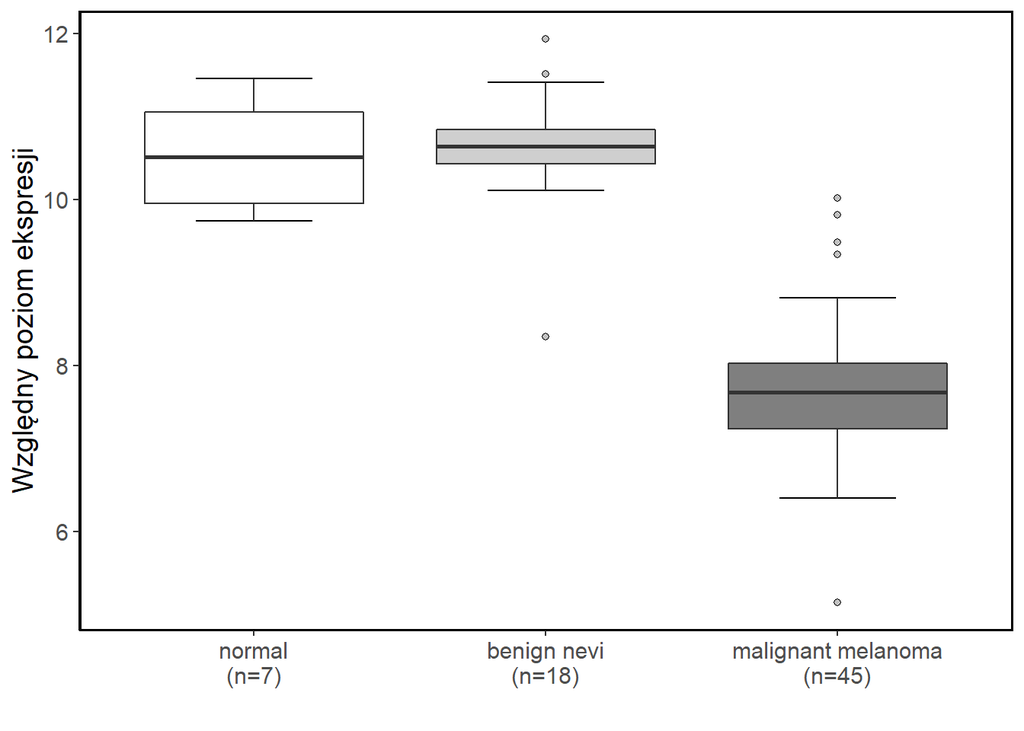

**Statystyka opisowa**

```
## # A tibble: 3 x 7
##   State               mean median maximum minimum    sd     N
##   <chr>              <dbl>  <dbl>   <dbl>   <dbl> <dbl> <int>
## 1 benign nevi        10.6   10.6     11.9    8.34 0.742    18
## 2 malignant melanoma  7.74   7.67    10.0    5.14 0.866    45
## 3 normal             10.5   10.5     11.5    9.74 0.681     7
```

**Test nieparametryczny**

Z uwagi na małą liczbę obserwacji do analizy istotności wyników wykorzystano test nieparametryczny Kruskala-Wallisa .

```
##
##  Kruskal-Wallis rank sum test
##
## data:  data$NormLog2_value by data$State
## Kruskal-Wallis chi-squared = 45.901, df = 2, p-value = 1.078e-10
```

Na podstawie otrzymanego wyniku (p-value < 0.05) możemy stwierdzić, że należy odrzucić hipotezę zerową i przyjąć hipotezę alternatywną, która mówi, że występują istotne statystycznie różnice pomiędzy badanymi grupami.

**Testy post-hoc**

```
## Dunn (1964) Kruskal-Wallis multiple comparison
```

```
##   p-values adjusted with the Bonferroni method.
```

```
##                         Comparison          Z      P.unadj        P.adj
## 1 benign nevi - malignant melanoma  6.1471216 7.890166e-10 2.367050e-09
## 2             benign nevi - normal  0.2013655 8.404128e-01 1.000000e+00
## 3      malignant melanoma - normal -3.9986625 6.370143e-05 1.911043e-04
```

Wartości p-value mniejsze od 0.05 oznaczają, że względny poziom ekspresji efryn między różnymi stanami chorobowymi jest istotny statystycznie. Dla receptora B6 test Dunna wykazał istotne statystycznie różnice w benign nevi-malignant melanoma oraz malignant melanoma-normal.

# Podsumowanie - receptory wykazujące różnice w poziomie ekspresji w zależności od stanu chorobowego

Istotne statystycznie różnice w pozimie ekspresji efryn dla czerniaków pierwotnych, łagodnych znamion i normalnych tkanek skóry uzyskano dla efryn **A1**, **A2**, **A3**, **A4**, **B1**, **B2**, **B3**, **B4** oraz**B6**.

**–>** Dla receptora **A1** test Dunna wykazał istotne statystycznie różnice w **benign nevi-malignant melanoma** oraz **malignant melanoma-normal**.

**–>** Dla receptora **A2** test Dunna wykazał istotne statystycznie różnice w **benign nevi-malignant melanoma** oraz **malignant melanoma-normal**.

**–>** Dla receptora **A3** test Dunna wykazał istotne statystycznie różnice w **benign nevi-normal** oraz **malignant melanoma-normal**.

**–>** Dla receptora **A4** test Dunna wykazał istotne statystycznie różnice w **benign nevi-malignant melanoma**.

**–>** Dla receptora **B1** test Dunna wykazał istotne statystycznie różnice w **benign nevi-malignant melanoma**.

**–>** Dla receptora **B2** test Dunna wykazał istotne statystycznie różnice w **benign nevi-malignant melanoma**.

**–>** Dla receptora **B3** test Dunna wykazał istotne statystycznie różnice w **benign nevi-malignant melanoma** oraz **malignant melanoma-normal**.

**–>** Dla receptora **B4** test Dunna wykazał istotne statystycznie różnice w **benign nevi-malignant melanoma** oraz **malignant melanoma-normal**.

**–>** Dla receptora **B6** test Dunna wykazał istotne statystycznie różnice w **benign nevi-malignant melanoma** oraz **malignant melanoma-normal**.